# Model Building and Selection Case (Using NMB Pretended Dataset)

Laban Masunga

2022-04-20

## Dataset Description and the intended outcome

A sports science experiment was conducted at NMB Bank where 6 randomly choose members of staff each supervised 5 different randomly selected participants to see if they could complete an exercise programme or not. On different occasions the participant undertook an exercise programme with different intensities and of different lengths. Half the participants had undertaken exercise training in the previous weeks and the others had not. The nmb_miniproject.txt (text file) (available via provides the data, which includes the following variables:

```
Staff -  i is the unique ID for the i^th staff member

Participant  - the j^th participant for the i^th member staff

complete - whether the participant completed the programme (1) or did not complete the program (0)

intensity - measure of the intensity of the programme (higher values are more intense)

length - length in minutes of the exercise programme

training - whether the participant took part in training (1) or did not take part in training (0)
```

This mini-project will look at fitting appropriate models, what can be concluded about the effect of the staff, participant, intensity, length and training on whether the participant completed the programme.

The primary areas to be covered will be:

```
(i) Fitting appropriate models to the data;

(ii) Using appropriate model selection techniques;

(iii) Drawing appropriate conclusions, aimed at a data scientist manager.
```

### Setting your directory and importing dataset

setwd(“C:/OFFICE_/NMB_quick_miniproject”)

### R Data Exploration

This section will give simple data exploration

```r
summary(nmbdata)
```

```
##      Staff      Participant    complete        intensity         length
##  Min.   :1.0   Min.   :1    Min.   :0.0000   Min.   :5.000   Min.   : 5.00
##  1st Qu.:2.0   1st Qu.:2    1st Qu.:0.0000   1st Qu.:5.500   1st Qu.: 8.75
##  Median :3.5   Median :3    Median :1.0000   Median :6.000   Median :12.50
##  Mean   :3.5   Mean   :3    Mean   :0.6833   Mean   :6.028   Mean   :12.50
##  3rd Qu.:5.0   3rd Qu.:4    3rd Qu.:1.0000   3rd Qu.:6.500   3rd Qu.:16.25
##  Max.   :6.0   Max.   :5    Max.   :1.0000   Max.   :7.000   Max.   :20.00
##     training
##  Min.   :0.0
##  1st Qu.:0.0
##  Median :0.5
##  Mean   :0.5
##  3rd Qu.:1.0
##  Max.   :1.0
```

### Doing simple checks, eg. dimension of dataset and any suspected missing values

```r
dim(nmbdata)
```

```
## [1] 120   6
```

```r
sum(is.na(nmbdata))
```

```
## [1] 0
```

### Including Simple Plots

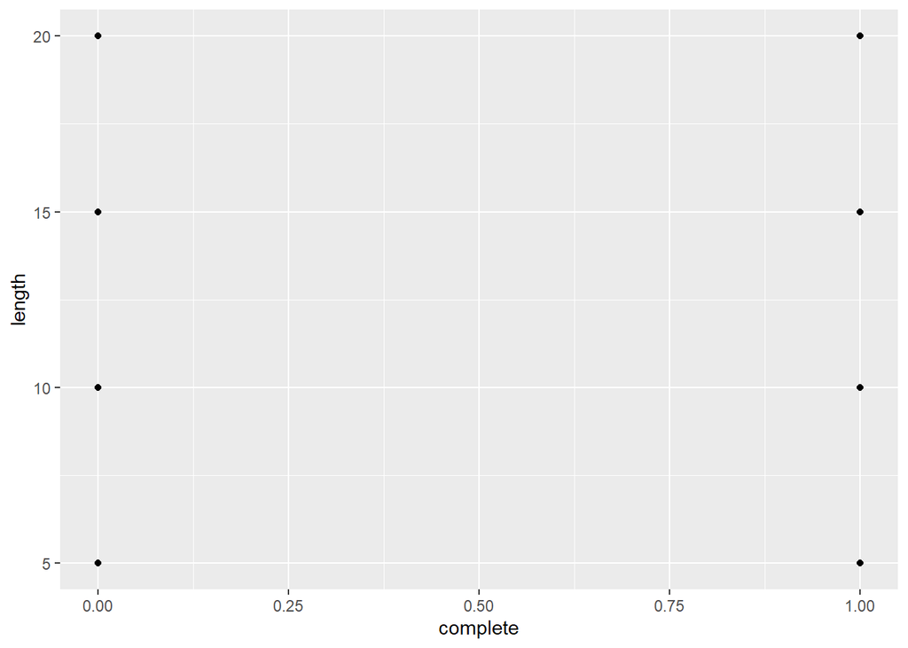

```r
library(ggplot2)
ggplot(data = nmbdata, mapping = aes(x = complete, y = length))+geom_point()
```

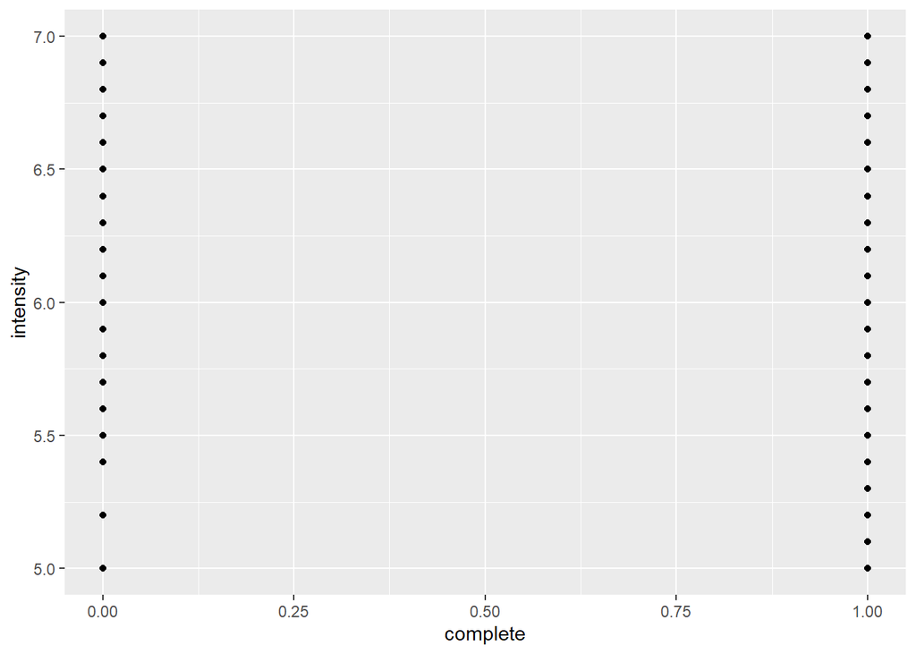

```r
ggplot(data = nmbdata, mapping = aes(x = complete, y = intensity))+geom_point()
```

### Doing some statistical analysis

```r
library(lme4)
modelilt <- glm(formula=complete~ intensity+length+factor(training),data = nmbdata,family = binomial())
summary(modelilt)
```

```
##
## Call:
## glm(formula = complete ~ intensity + length + factor(training),
##     family = binomial(), data = nmbdata)
##
## Deviance Residuals:
##     Min       1Q   Median       3Q      Max
## -2.2039  -1.0953   0.6171   0.8735   1.4191
##
## Coefficients:
##                   Estimate Std. Error z value Pr(>|z|)
## (Intercept)        5.41507    2.24397   2.413  0.01581 *
## intensity         -0.82595    0.36032  -2.292  0.02189 *
## length            -0.01238    0.03752  -0.330  0.74138
## factor(training)1  1.17479    0.42699   2.751  0.00594 **
## ---
## Signif. codes:  0 '***' 0.001 '**' 0.01 '*' 0.05 '.' 0.1 ' ' 1
##
## (Dispersion parameter for binomial family taken to be 1)
##
##     Null deviance: 149.84  on 119  degrees of freedom
## Residual deviance: 136.46  on 116  degrees of freedom
## AIC: 144.46
##
## Number of Fisher Scoring iterations: 3
```

Note that if the `echo` parameter will be changed to ‘FALSE’ or ‘F’, the code chunk will prevent printing of the R code that generated the plot.

# Main Analysis

Using the t-test both Intensity and training have p-values < 0.05, so have covariate values significantly different zero. Suggesting these covariates should be included in the model. However, as the p-value for length is 0.74, this not significantly different from zero, so should not be included in the model.

### R code for fitting a selection of other models:

```r
 modelil <- glm(formula=complete~ intensity+length,data = nmbdata,family = binomial())
 modelit <- glm(formula=complete~ intensity+factor(training),data = nmbdata,family = binomial())
 modellt <- glm(formula=complete~ length+factor(training),data = nmbdata,family = binomial())
modeli <- glm(formula=complete~ intensity,data = nmbdata,family = binomial())
 modell <- glm(formula=complete~ length,data = nmbdata,family = binomial())
 modelt <- glm(formula=complete~ factor(training),data = nmbdata,family = binomial())
 modelconst <- glm(formula=complete~ 1,data = nmbdata,family = binomial())
```

### AIC model selection:

```r
library(lmerTest)
 AICvalues <- c(AIC(modelilt),AIC(modelil),AIC(modelit),AIC(modellt),AIC(modeli),AIC(modell),AIC(modelt), AIC(modelconst))
 modelname <- c("intensity+length+training", "intensity+length", "intensity+training","length+training","intensity","length","training","const")
 AICvaluesr <- round(AICvalues,digits=2)
 deltaAIC <-AICvalues-min(AICvalues)
 deltaAICr <-round(deltaAIC,digits=2)
 AICweight <- round(exp(-deltaAIC/2)/sum(exp(-deltaAIC/2)),digits=2)
 AICtable <- data.frame(modelname,AICvaluesr,deltaAICr,AICweight)
 colnames(AICtable ) <- c("Model", "AIC","Delta AIC","AIC weight")
 print(AICtable)
```

```
##                       Model    AIC Delta AIC AIC weight
## 1 intensity+length+training 144.46      1.89       0.23
## 2          intensity+length 150.52      7.95       0.01
## 3        intensity+training 142.57      0.00       0.59
## 4           length+training 148.02      5.45       0.04
## 5                 intensity 148.68      6.10       0.03
## 6                    length 153.72     11.14       0.00
## 7                  training 146.16      3.58       0.10
## 8                     const 151.84      9.27       0.01
```

The best model includes intensity and training, other possible models include all three covariates or just training (models with AIC weight > 0.1)

### Analysis of Deviance:

#### Level 1 Analysis of Deviance - compare to constant model

```r
 Modellist <- list( )
 Modellist[[1]] <- modeli
 Modellist[[2]] <- modell
 Modellist[[3]] <- modelt
 modelcompare <- modelconst
 modelname <- c("intensity", "length","training")
 # Create Analysis of Deviance
 dev <- rep(0,(length(Modellist)))
 for (i in 1:(length(Modellist))){dev[i]=Modellist[[i]]$deviance}
 devcompare <- modelcompare$deviance
 DF <- rep(0,(length(Modellist)))
 for (i in 1:(length(Modellist))){DF[i]=Modellist[[i]]$df.residual}
 DFcompare <- modelcompare$df.residual
 diffdev=devcompare-dev
 diffDF=DFcompare-DF
 pval=pchisq(diffdev, df=diffDF, lower.tail=FALSE)
 devtable = data.frame(modelname,diffdev,diffDF,pval)
 colnames(devtable) <- c("Model", "Diff Deviance","Diff DF","p-value")
 print(devtable)
```

```
##       Model Diff Deviance Diff DF     p-value
## 1 intensity     5.1629956       1 0.023073069
## 2    length     0.1232785       1 0.725505589
## 3  training     7.6834109       1 0.005573073
```

Both intensity and training have p-values < 0.05, training has smallest p-values, so use to compare at level 2

#### Level 2 – compare to training

```r
 Modellist <- list( )
 Modellist[[1]] <- modelit
 Modellist[[2]] <- modellt
 modelcompare <- modelt
 modelname <- c("intensity+training","length+training")

 # Create Analysis of Deviance
 dev <- rep(0,(length(Modellist)))
 for (i in 1:(length(Modellist))){dev[i]=Modellist[[i]]$deviance}
 devcompare <- modelcompare$deviance
 DF <- rep(0,(length(Modellist)))
 for (i in 1:(length(Modellist))){DF[i]=Modellist[[i]]$df.residual}
 DFcompare <- modelcompare$df.residual
 diffdev=devcompare-dev
 diffDF=DFcompare-DF
 pval=pchisq(diffdev, df=diffDF, lower.tail=FALSE)
 devtable = data.frame(modelname,diffdev,diffDF,pval)
 colnames(devtable) <- c("Model", "Diff Deviance","Diff DF","p-value")
 print(devtable)
```

```
##                Model Diff Deviance Diff DF    p-value
## 1 intensity+training     5.5822329       1 0.01814358
## 2    length+training     0.1315603       1 0.71681967
```

Only adding intensity has a p-value < 0.05. Compare to intensity + training at the next level.

#### Level 3 Analysis of Deviance - compare to training+intensity

```r
 Modellist <- list( )
 Modellist[[1]] <- modelilt
 modelcompare <- modelit
 modelname <- c("intensity+length+training")

 # Create Analysis of Deviance
 dev <- rep(0,(length(Modellist)))
 for (i in 1:(length(Modellist))){dev[i]=Modellist[[i]]$deviance}
 devcompare <- modelcompare$deviance
 DF <- rep(0,(length(Modellist)))
 for (i in 1:(length(Modellist))){DF[i]=Modellist[[i]]$df.residual}
 DFcompare <- modelcompare$df.residual
 diffdev=devcompare-dev
 diffDF=DFcompare-DF
 pval=pchisq(diffdev, df=diffDF, lower.tail=FALSE)
 devtable = data.frame(modelname,diffdev,diffDF,pval)
 colnames(devtable) <- c("Model", "Diff Deviance","Diff DF","p-value")
 print(devtable)
```

```
##                       Model Diff Deviance Diff DF   p-value
## 1 intensity+length+training     0.1090217       1 0.7412606
```

p-value > 0.05, so do not include length. Therefore, best model is intensity + training. This is the same as the best model according to AIC.

### Now consider adding random participant effects to this model:

#### Model with just staff:

```r
 modelits <- glmer(formula=complete~ intensity+factor(training)+(1|Staff),data = nmbdata,family = binomial())
```

```
## boundary (singular) fit: see help('isSingular')
```

#### Model with staff and participant:

```r
 modelitsp <- glmer(formula=complete~ intensity+factor(training)+(1|Staff/Participant),data = nmbdata,family = binomial()) # ingnore the error boundary (singular) fit: see help('isSingular')
```

```
## boundary (singular) fit: see help('isSingular')
```

### LRT for whether need to add random staff effect

```r
 LRT <- 2*(logLik(modelits)[1]-logLik(modelit)[1])
 pvalue <- 1-pchisq(LRT, df=1)
 LRTresults <- data.frame(LRT,pvalue)
 print(LRTresults)
```

```
##            LRT    pvalue
## 1 2.842171e-14 0.9999999
```

As the p-value > 0.05, this suggests there is no evidence of a random staff effect.

### AIC model selection:

```r
 AIC(modelit,modelits,modelitsp)
```

```
##           df      AIC
## modelit    3 142.5739
## modelits   4 144.5739
## modelitsp  5 145.2725
```

According to AIC the best model has intensity and training but not a random staff or participant effect.

The LRT and AIC agree that the best model includes intensity and training.

### Results for best model:

```r
 summary(modelit)
```

```
##
## Call:
## glm(formula = complete ~ intensity + factor(training), family = binomial(),
##     data = nmbdata)
##
## Deviance Residuals:
##     Min       1Q   Median       3Q      Max
## -2.1929  -1.1308   0.6164   0.8848   1.4068
##
## Coefficients:
##                   Estimate Std. Error z value Pr(>|z|)
## (Intercept)         5.2742     2.2013   2.396  0.01658 *
## intensity          -0.8284     0.3607  -2.297  0.02163 *
## factor(training)1   1.1778     0.4270   2.758  0.00581 **
## ---
## Signif. codes:  0 '***' 0.001 '**' 0.01 '*' 0.05 '.' 0.1 ' ' 1
##
## (Dispersion parameter for binomial family taken to be 1)
##
##     Null deviance: 149.84  on 119  degrees of freedom
## Residual deviance: 136.57  on 117  degrees of freedom
## AIC: 142.57
##
## Number of Fisher Scoring iterations: 3
```

In conclusion, the best model according to AIC includes both intensity and training, but not length and not a random staff nor participant effect. Other model selection (deviance and LRT) techniques agree with this conclusion.

The parameter estimates and their standard errors are as follows:

```r
Parameter   <-c('Intercept', 'Intensity','Training_1')
Estimate<-c(5.27, -0.83, 1.18)
Standard_Error<-c(2.20, 0.36, 0.43)
data.frame(Parameter,Estimate,Standard_Error)
```

```
##    Parameter Estimate Standard_Error
## 1  Intercept     5.27           2.20
## 2  Intensity    -0.83           0.36
## 3 Training_1     1.18           0.43
```

As the intensity increases the probability of completing decreases. The participant is more likely to complete if they took part in training (1 represents took part in program).